# Sparse Partial correlation ON Gene Expression with SPONGE

Markus List

2017-06-07

## Short description

SPONGE is the first method to solve the computationally demanding task of reporting significant ceRNA interactions efficiently on a genome-wide scale. Beyond ceRNAs, this method is well suited to infer other types of regulatory interactions such as transcription factor regulation.

## Introduction

MicroRNAs (miRNAs) are small 19-22 nucleotide long molecules that facilitate the degradation of messenger RNA (mRNA) transcripts targeted via matching seed sequences. The competing endogenous RNA (ceRNA) hypothesis suggests that mRNAs that possess binding sites for the same miRNAs are in competition. This motivates the existence of so-called sponges, i.e., genes that exert strong regulatory control via miRNA binding in a ceRNA interaction network. It is currently an unsolved problem how to estimate miRNA-mediated ceRNA interactions genome-wide. The most widely used approach considers miRNA and mRNA expression jointly measured for the same cell state. Several partial association methods have been proposed for determining ceRNA interaction strength using [conditional mutual information](https://www.ncbi.nlm.nih.gov/pubmed/22000015) or [partial correlation](https://www.ncbi.nlm.nih.gov/pubmed/25033876), for instance.

However, we identified three key limitations of existing approaches that prevent the construction of an accurate genome-wide ceRNA interaction network: (i) none of the existing methods considers the combinatorial effect of several miRNAs; (ii) due to the computational demand, the inference of a ceRNA interaction for all putative gene-miRNA-gene interactions in the human genome is prohibitive; (iii) an efficient strategy for determining the significance of inferred ceRNA interactions is missing, and thus important parameters of the system are neglected.

To overcome these challenges, we developed a novel method called Sparse partial correlation on gene expression (SPONGE). We reduce the computational complexity of constructing a genome-wide ceRNA interaction network in several steps. First, we consider only miRNA-gene interactions that are either predicted or experimentally validated. Second, we retain only miRNA-gene interactions that have a negative coefficient in a regularized regression model. Third, instead of each gene-miRNA-gene triplet, we compute a single sensitivity correlation (correlation - partial correlation) for each gene-gene pair given all shared miRNAs that pass the above filter as putative regulators. Finally, we derived the first mathematical formulation to simulate the null distribution of the process for different parameters of the system: number of miRNAs, correlation between genes and sample number. Our formulation enables the computation of empirical p-values for the statistic in a very efficient manner, an order of magnitude faster than previous methods. Analyses revealed that previous studies have underestimated the effect of these parameters in their network inference. Network centrality measures can be applied to SPONGE inferred ceRNA networks to reveal known and novel sponges, many of which are potential biomarkers.

Further details demonstrating how SPONGE improves over the state of the art and how SPONGE inferred ceRNA networks can be used for biomarker discovery will be available in our paper (manuscript submitted, link will be included here at a later point).

## General Workflow

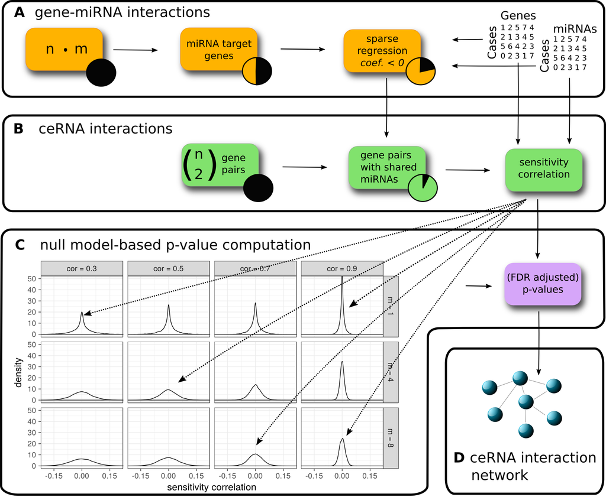

Overview of the SPONGE workflow. (A) Predicted and/or experimentally validated gene-miRNA interactions are subjected to regularized regression on gene and miRNA expression data. Interactions with negative coefficients for miRNA regulators are retained since they indicate miRNA induced inhibition of gene expression. (B) We compute sensitivity correlation coefficients for gene pairs based on shared miRNAs identified in (A). (C) Given the sample number, we compute empirical null models for various gene-gene correlation coefficients (k, columns) and number of miRNAs (m, rows). Sensitivity correlation coefficients are assigned to the best matching null model and a p-value is inferred. (D) After multiple testing correction, significant ceRNA interactions can be used to construct a genome-wide, disease or tissue-specific ceRNA interaction network. In the following hands-on tutorial, we will highlight how each of these steps can be achieved with the SPONGE R package.

## (A) gene-miRNA interactions

We start with loading the package and its dependencies

```r
library(SPONGE)
```

SPONGE comes with a very small example gene and miRNA expression dataset useful for illustrating functionality. We suggest obtaining larger expression data sets via the GEOquery or TCGAbiolinks R packages, for instance. After loading the package, the example datasets can be accessed:

Gene expression:

```r
head(gene_expr)
```

|  | UST | FBXO32 | TMEM132A | CTTNBP2 | MITF | RANBP3L | DNMT3A | NTN4 |
| --- | --- | --- | --- | --- | --- | --- | --- | --- |
| TCGA-CC-A7IH | 9.763889 | 8.664702 | 8.143475 | 2.004897 | 5.449300 | 5.7478519 | 9.482231 | 8.355215 |
| TCGA-DD-A3A9 | 4.186326 | 5.754722 | 9.618885 | 2.150949 | 5.330171 | 0.7554858 | 9.985951 | 6.665077 |
| TCGA-CC-A5UE | 2.394404 | 5.514267 | 5.041414 | 1.045723 | 5.688147 | 3.1671973 | 9.742771 | 8.601548 |
| TCGA-BC-A3KF | 3.378858 | 5.423568 | 7.644005 | 7.085019 | 5.983949 | 1.1212144 | 8.863079 | 8.595803 |
| TCGA-DD-A3A6 | 8.016376 | 10.199888 | 9.349632 | 3.828246 | 8.824847 | 5.0691178 | 7.681065 | 8.423871 |

miRNA expression:

```r
head(mir_expr)
```

|  | MIMAT0000070 | MIMAT0000680 | MIMAT0000222 | MIMAT0000460 | MIMAT0000243 | MIMAT0000093 | MIMAT0000417 | MIMAT0000104 |
| --- | --- | --- | --- | --- | --- | --- | --- | --- |
| TCGA-CC-A7IH | 8.110843 | 7.637696 | 14.397147 | 13.337312 | 17.77343 | 12.13092 | 7.828879 | 8.164267 |
| TCGA-DD-A3A9 | 9.425956 | 7.141432 | 14.627978 | 13.753494 | 13.84755 | 13.15549 | 5.964436 | 5.941846 |
| TCGA-CC-A5UE | 10.017687 | 8.191404 | 16.030031 | 14.579990 | 16.12510 | 13.80266 | 7.215886 | 6.865899 |
| TCGA-BC-A3KF | 11.260798 | 7.721752 | 17.036269 | 15.497766 | 16.15116 | 11.98398 | 8.113364 | 7.540799 |
| TCGA-DD-A3A6 | 7.717456 | 7.700341 | 7.605197 | 7.191296 | 13.79406 | 11.28618 | 8.095353 | 8.289970 |

Note that the expected format for both expression matrices is that columns correspond to genes / miRNAs and rows correspond to samples. Please make sure that samples are ordered identically in both matrices and that each sample has an entry in both matrices (paired gene and miRNA expression data).

SPONGE uses a two-tier filtering approach to identify gene-miRNA interactions.

First, the user may incorporate prior knowledge to narrow down the number of gene-miRNA interactions. This could be, for instance, the output of a sequence-based miRNA target prediction software such as [TargetScan](http://www.targetscan.org/vert_71/) or [miRcode](http://www.mircode.org) or experimental evidence obtained from databases such as [miRTarBase](http://www.mirtarbase.mbc.nctu.edu.tw/) or [LncBase](http://carolina.imis.athena-innovation.gr/diana_tools/web/index.php?r=lncbasev2%2Findex). The user is free to use his or her trusted resource(s) and only needs to make sure that the miRNA-gene interactions are formatted as SPONGE expects it:

SPONGE allows for an arbitrary number of miRNA-gene interaction matrices $I$ that need to be formatted with genes $G$ in rows and miRNAs $M$ in columns. For each element $i_{g, m} \in I$, we consider the miRNA-gene interaction if $i_{g, m} > 0$. While SPONGE only checks if an entry is zero or not, this approach allows for additional information such as the respective number of binding sites or a score to be encoded in the matrix for later analysis. We included examples for TargetScan:

```r
head(targetscan)
```

|  | MIMAT0000062 | MIMAT0000063 | MIMAT0000064 | MIMAT0000065 | MIMAT0000066 |
| --- | --- | --- | --- | --- | --- |
| A1BG | 0 | 0 | 0 | 0 | 0 |
| A1CF | 1 | 1 | 1 | 1 | 1 |
| A4GNT | 0 | 0 | 0 | 0 | 0 |
| AACS | 0 | 0 | 0 | 0 | 0 |
| AAED1 | 0 | 0 | 0 | 0 | 0 |

…and miRcode

```r
head(mircode)
```

|  | MIMAT0000062 | MIMAT0000063 | MIMAT0000064 | MIMAT0000065 | MIMAT0000066 |
| --- | --- | --- | --- | --- | --- |
| 5S_rRNA | 0 | 0 | 0 | 0 | 0 |
| 7SK | 8 | 8 | 8 | 8 | 8 |
| A1BG | 0 | 0 | 0 | 0 | 0 |
| A1CF | 1 | 1 | 1 | 1 | 1 |
| A2LD1 | 0 | 0 | 0 | 0 | 0 |

Note that the gene and miRNA identifiers in the interaction matrices need to be of the same type and format as the ones used in the expression matrices. Otherwise they can not be matched by SPONGE.

We apply step A of the SPONGE workflow as follows:

```
## 2017-06-07 16:53:21 INFO::Removing genes and miRNAs with zero variance
## 2017-06-07 16:53:21 INFO::merging miRNA target database annotations
```

The result is a list of genes, where each entry holds a data frame with retained miRNAs and their coefficients (or p-values in case the F-test is used). Note that the mir_predicted_targets parameter may also be NULL. In this case, no prior knowledge is used and all putative miRNA-gene interactions are used in elasticnet regression.

```r
genes_miRNA_candidates[1:2]
```

```
## $ASAP2
##           mirna  coefficient
## 1  MIMAT0000068 -0.051649421
## 3  MIMAT0000070 -0.015053842
## 4  MIMAT0000074 -0.052265559
## 5  MIMAT0000076 -0.250888352
## 6  MIMAT0000077 -0.183891636
## 7  MIMAT0000081 -0.089668214
## 8  MIMAT0000086 -0.017512336
## 10 MIMAT0000091 -0.220616282
## 11 MIMAT0000092 -0.188160276
## 13 MIMAT0000099 -0.011932207
## 14 MIMAT0000100 -0.094049902
## 15 MIMAT0000101 -0.168840825
## 16 MIMAT0000103 -0.060429851
```

[output cut: 21 more lines]

## (B) ceRNA interactions

In the second step of the SPONGE workflow, we identify ceRNA actions candidates. SPONGE uses the information from (A) and checks for each pair of genes if they share one or more miRNAs with regulatory effect. This reduces the putative number of ceRNA interactions $n\choose 2$ to consider dramatically. Next, SPONGE uses the ppcor R package to compute multiple miRNA sensitivity correlation () values. Note that this is a generalization of sensitivity correlation as defined by [Paci et al.](https://www.ncbi.nlm.nih.gov/pubmed/25033876). These values capture the joint contribution of several miRNAs on the ceRNA regulation of two genes while accounting for their cross-correlation:

$$\begin{eqnarray}\label{formula_scor}
mscor(g_1, g_2, M) & = & cor(g_1, g_2) - pcor(g_1, g_2 | M) \.
\end{eqnarray}$$

where $M = {m_1, ..., m_i}$ and $i$ the number of shared miRNAs between $g_1$ and $g_2$.

We apply step B of the SPONGE workflow as follows:

[output not shown]

[output cut: 547 more lines]

[output not shown]

The result is a data table with both genes (A and B), the number of miRNAs (), gene-gene correlation (), partial correlation given all miRNAs () and the values, i.e. $mscor = cor - pcor$:

```r
head(ceRNA_interactions)
```

| geneA | geneB | df | cor | pcor | scor |
| --- | --- | --- | --- | --- | --- |
| UST | FBXO32 | 4 | 0.2529669 | 0.0254287 | 0.2275383 |
| UST | TMEM132A | 5 | 0.1304111 | 0.0398484 | 0.0905627 |
| FBXO32 | TMEM132A | 8 | 0.1774636 | 0.0094978 | 0.1679658 |
| UST | CTTNBP2 | 2 | 0.4189384 | 0.3586177 | 0.0603208 |
| FBXO32 | CTTNBP2 | 3 | 0.3036081 | 0.2681161 | 0.0354920 |
| TMEM132A | CTTNBP2 | 4 | 0.3630503 | 0.2182242 | 0.1448262 |

## (C) Null-model-based p-value computation

A theory for the random distribution of values did not exist and previous studies using sensitivity correlation either used simple thresholds or random background distributions inferred from random triplets. Simulation experiments show that this approach does not account for the fact that the distribution of parameters is strongly affected by gene-gene correlation and the number of samples considred.

This motivated us to develop a strategy for inferring the distribution of values under the null hypothesis that miRNAs do not affect the correlation between two genes, i.e. $mscor = 0$. At the basis of this is a method for sampling random covariance matrices under this null hypothesis in which we control i) the gene-gene correlation and ii) the number of miRNAs which corresponds to the number of columns in the covariance matrix. See [Computing additional covariance matrices] for details on how to construct these matrices. Since this sampling procedure is computationally intensive, we include pre-computed sets of covariance matrices for a range of parameter combinations, i.e. 10 covariance matrices for each pair of gene-gene correlation $cor = (0.2, ..., 0.9)$ and number of miRNAs $m = (1, 2,...,8)$. Using these covariance matrices and the package mvrnorm allows us to sample from the random distribution of values with respect to the available number of samples (the number of rows in our expression matrices):

```
## 2017-06-07 16:54:01 INFO::Simulating data for null model of partition m = 1 and k = 0.2
## 2017-06-07 16:54:02 INFO::Simulating data for null model of partition m = 1 and k = 0.3
## 2017-06-07 16:54:03 INFO::Simulating data for null model of partition m = 1 and k = 0.4
## 2017-06-07 16:54:03 INFO::Simulating data for null model of partition m = 1 and k = 0.5
## 2017-06-07 16:54:04 INFO::Simulating data for null model of partition m = 1 and k = 0.6
## 2017-06-07 16:54:04 INFO::Simulating data for null model of partition m = 1 and k = 0.7
## 2017-06-07 16:54:05 INFO::Simulating data for null model of partition m = 1 and k = 0.8
## 2017-06-07 16:54:06 INFO::Simulating data for null model of partition m = 1 and k = 0.9
## 2017-06-07 16:54:06 INFO::Simulating data for null model of partition m = 2 and k = 0.2
## 2017-06-07 16:54:07 INFO::Simulating data for null model of partition m = 2 and k = 0.3
## 2017-06-07 16:54:07 INFO::Simulating data for null model of partition m = 2 and k = 0.4
## 2017-06-07 16:54:08 INFO::Simulating data for null model of partition m = 2 and k = 0.5
## 2017-06-07 16:54:08 INFO::Simulating data for null model of partition m = 2 and k = 0.6
## 2017-06-07 16:54:09 INFO::Simulating data for null model of partition m = 2 and k = 0.7
## 2017-06-07 16:54:10 INFO::Simulating data for null model of partition m = 2 and k = 0.8
## 2017-06-07 16:54:10 INFO::Simulating data for null model of partition m = 2 and k = 0.9
## 2017-06-07 16:54:11 INFO::Simulating data for null model of partition m = 3 and k = 0.2
## 2017-06-07 16:54:11 INFO::Simulating data for null model of partition m = 3 and k = 0.3
## 2017-06-07 16:54:12 INFO::Simulating data for null model of partition m = 3 and k = 0.4
## 2017-06-07 16:54:12 INFO::Simulating data for null model of partition m = 3 and k = 0.5
## 2017-06-07 16:54:13 INFO::Simulating data for null model of partition m = 3 and k = 0.6
## 2017-06-07 16:54:14 INFO::Simulating data for null model of partition m = 3 and k = 0.7
## 2017-06-07 16:54:14 INFO::Simulating data for null model of partition m = 3 and k = 0.8
## 2017-06-07 16:54:15 INFO::Simulating data for null model of partition m = 3 and k = 0.9
## 2017-06-07 16:54:15 INFO::Simulating data for null model of partition m = 4 and k = 0.2
## 2017-06-07 16:54:16 INFO::Simulating data for null model of partition m = 4 and k = 0.3
## 2017-06-07 16:54:17 INFO::Simulating data for null model of partition m = 4 and k = 0.4
## 2017-06-07 16:54:17 INFO::Simulating data for null model of partition m = 4 and k = 0.5
## 2017-06-07 16:54:18 INFO::Simulating data for null model of partition m = 4 and k = 0.6
## 2017-06-07 16:54:19 INFO::Simulating data for null model of partition m = 4 and k = 0.7
## 2017-06-07 16:54:19 INFO::Simulating data for null model of partition m = 4 and k = 0.8
## 2017-06-07 16:54:20 INFO::Simulating data for null model of partition m = 4 and k = 0.9
## 2017-06-07 16:54:20 INFO::Simulating data for null model of partition m = 5 and k = 0.2
## 2017-06-07 16:54:21 INFO::Simulating data for null model of partition m = 5 and k = 0.3
## 2017-06-07 16:54:22 INFO::Simulating data for null model of partition m = 5 and k = 0.4
## 2017-06-07 16:54:22 INFO::Simulating data for null model of partition m = 5 and k = 0.5
## 2017-06-07 16:54:23 INFO::Simulating data for null model of partition m = 5 and k = 0.6
## 2017-06-07 16:54:23 INFO::Simulating data for null model of partition m = 5 and k = 0.7
## 2017-06-07 16:54:24 INFO::Simulating data for null model of partition m = 5 and k = 0.8
## 2017-06-07 16:54:24 INFO::Simulating data for null model of partition m = 5 and k = 0.9
```

[output cut: 9 more lines]

```
## 2017-06-07 16:54:31 INFO::Simulating data for null model of partition m = 7 and k = 0.3
## 2017-06-07 16:54:31 INFO::Simulating data for null model of partition m = 7 and k = 0.4
## 2017-06-07 16:54:32 INFO::Simulating data for null model of partition m = 7 and k = 0.5
## 2017-06-07 16:54:32 INFO::Simulating data for null model of partition m = 7 and k = 0.6
## 2017-06-07 16:54:33 INFO::Simulating data for null model of partition m = 7 and k = 0.7
## 2017-06-07 16:54:34 INFO::Simulating data for null model of partition m = 7 and k = 0.8
## 2017-06-07 16:54:34 INFO::Simulating data for null model of partition m = 7 and k = 0.9
## 2017-06-07 16:54:34 INFO::Simulating data for null model of partition m = 8 and k = 0.2
## 2017-06-07 16:54:35 INFO::Simulating data for null model of partition m = 8 and k = 0.3
## 2017-06-07 16:54:36 INFO::Simulating data for null model of partition m = 8 and k = 0.4
## 2017-06-07 16:54:36 INFO::Simulating data for null model of partition m = 8 and k = 0.5
## 2017-06-07 16:54:37 INFO::Simulating data for null model of partition m = 8 and k = 0.6
## 2017-06-07 16:54:38 INFO::Simulating data for null model of partition m = 8 and k = 0.7
## 2017-06-07 16:54:38 INFO::Simulating data for null model of partition m = 8 and k = 0.8
## 2017-06-07 16:54:39 INFO::Simulating data for null model of partition m = 8 and k = 0.9
```

We can plot the result of these simulations to see how the distribution is affected by gene-gene correlation and number of miRNAs:

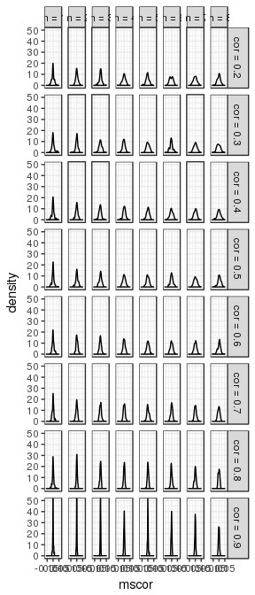

```r
sponge_plot_simulation_results(mscor_null_model)
```

Obviously, this is a bit crude since we only samples 100 data points for each of the partitions to keep the compile time of the vignette in check. The default for the number of data sets to be sampled is muche more reasonable with a value of 1e6.

After computing p-values for all coefficients, we apply multiple testing correction for all values within a partition, accounting for the fact that null models with low gene-gene correlation will be frequented substantially more often than those with high gene-gene correlation. To infer p-values we do the following:

```
## 2017-06-07 16:54:41 INFO::Computing empirical p-values for SPONGE results.
## 2017-06-07 16:54:41 INFO::Computing p-values for partition m = 1 and k = 0.2
## 2017-06-07 16:54:41 INFO::Computing p-values for partition m = 1 and k = 0.3
## 2017-06-07 16:54:41 INFO::Computing p-values for partition m = 2 and k = 0.2
## 2017-06-07 16:54:41 INFO::Computing p-values for partition m = 2 and k = 0.4
## 2017-06-07 16:54:41 INFO::Computing p-values for partition m = 2 and k = 0.5
## 2017-06-07 16:54:41 INFO::Computing p-values for partition m = 3 and k = 0.2
## 2017-06-07 16:54:41 INFO::Computing p-values for partition m = 3 and k = 0.3
## 2017-06-07 16:54:41 INFO::Computing p-values for partition m = 3 and k = 0.4
## 2017-06-07 16:54:41 INFO::Computing p-values for partition m = 3 and k = 0.6
## 2017-06-07 16:54:41 INFO::Computing p-values for partition m = 4 and k = 0.2
## 2017-06-07 16:54:41 INFO::Computing p-values for partition m = 4 and k = 0.3
## 2017-06-07 16:54:41 INFO::Computing p-values for partition m = 4 and k = 0.4
## 2017-06-07 16:54:41 INFO::Computing p-values for partition m = 4 and k = 0.5
## 2017-06-07 16:54:41 INFO::Computing p-values for partition m = 5 and k = 0.2
## 2017-06-07 16:54:41 INFO::Computing p-values for partition m = 5 and k = 0.3
## 2017-06-07 16:54:41 INFO::Computing p-values for partition m = 5 and k = 0.4
## 2017-06-07 16:54:41 INFO::Computing p-values for partition m = 5 and k = 0.5
## 2017-06-07 16:54:41 INFO::Computing p-values for partition m = 5 and k = 0.6
## 2017-06-07 16:54:41 INFO::Computing p-values for partition m = 5 and k = 0.7
## 2017-06-07 16:54:41 INFO::Computing p-values for partition m = 6 and k = 0.2
## 2017-06-07 16:54:41 INFO::Computing p-values for partition m = 6 and k = 0.3
## 2017-06-07 16:54:42 INFO::Computing p-values for partition m = 6 and k = 0.4
## 2017-06-07 16:54:42 INFO::Computing p-values for partition m = 6 and k = 0.5
## 2017-06-07 16:54:42 INFO::Computing p-values for partition m = 7 and k = 0.2
## 2017-06-07 16:54:42 INFO::Computing p-values for partition m = 7 and k = 0.3
## 2017-06-07 16:54:42 INFO::Computing p-values for partition m = 7 and k = 0.4
## 2017-06-07 16:54:42 INFO::Computing p-values for partition m = 7 and k = 0.5
## 2017-06-07 16:54:42 INFO::Computing p-values for partition m = 7 and k = 0.6
## 2017-06-07 16:54:42 INFO::Computing p-values for partition m = 8 and k = 0.2
## 2017-06-07 16:54:42 INFO::Computing p-values for partition m = 8 and k = 0.3
## 2017-06-07 16:54:42 INFO::Computing p-values for partition m = 8 and k = 0.4
## 2017-06-07 16:54:42 INFO::Computing p-values for partition m = 8 and k = 0.5
## 2017-06-07 16:54:42 INFO::Computing p-values for partition m = 8 and k = 0.6
## 2017-06-07 16:54:42 INFO::Computing p-values for partition m = 8 and k = 0.7
## 2017-06-07 16:54:42 INFO::Computing p-values for partition m = 8 and k = 0.8
## 2017-06-07 16:54:42 INFO::Finished computing p-values.
```

Note that the parameter simulated.data can also be NULL. In this case, the null models are computed on the fly. The above method adds two additional columns to the ceRNA results, namely $p.val$ and $p.adj$.

```r
head(ceRNA_interactions_sign)
```

| geneA | geneB | df | cor | pcor | scor | p.val | p.adj |
| --- | --- | --- | --- | --- | --- | --- | --- |
| CBR4 | SLC14A1 | 1 | 0.1977875 | 0.1783895 | 0.0193980 | 0.2100000 | 0.2100000 |
| ENO2 | DCLK2 | 1 | 0.2891145 | 0.1267682 | 0.1623463 | 0.0027473 | 0.0000000 |
| FBXO32 | SPNS2 | 2 | 0.1412484 | 0.1362691 | 0.0049793 | 0.4100000 | 0.4100000 |
| CTTNBP2 | ENO2 | 2 | 0.2130922 | 0.0816591 | 0.1314331 | 0.0027473 | 0.0000000 |
| CTTNBP2 | SIAE | 2 | 0.1952808 | 0.0453428 | 0.1499380 | 0.0027473 | 0.0000000 |
| MITF | TET1 | 2 | 0.1172753 | 0.0919066 | 0.0253687 | 0.2100000 | 0.2333333 |

## (D) ceRNA interaction network

The last step is fairly straight-forward. We decide on an FDR cutoff for selecting significant ceRNA interactions, e.g. FDR < 0.2 and extract those from the result.

```r
ceRNA_interactions_fdr <- ceRNA_interactions_sign[p.adj < 0.2,]
```

| geneA | geneB | df | cor | pcor | scor | p.val | p.adj |
| --- | --- | --- | --- | --- | --- | --- | --- |
| ENO2 | DCLK2 | 1 | 0.2891145 | 0.1267682 | 0.1623463 | 0.0027473 | 0.0000 |
| CTTNBP2 | ENO2 | 2 | 0.2130922 | 0.0816591 | 0.1314331 | 0.0027473 | 0.0000 |
| CTTNBP2 | SIAE | 2 | 0.1952808 | 0.0453428 | 0.1499380 | 0.0027473 | 0.0000 |
| FBXO32 | SLC14A1 | 2 | 0.1232761 | 0.0369657 | 0.0863105 | 0.0100000 | 0.0125 |
| TMEM132A | SLC14A1 | 2 | 0.2178924 | 0.0822433 | 0.1356491 | 0.0027473 | 0.0000 |
| ENO2 | SLC14A1 | 2 | 0.1031173 | -0.0890753 | 0.1921926 | 0.0027473 | 0.0000 |

In this artificial example we do not achieve very impressive results. However, when applying SPONGE to TCGA liver cancer data (364 samples), we were able to obtain more than 400,000 interactions at FDR < 0.01. This corresponds to 0.9% of the putative interactions (for details we refer you to the (yet) unpublished manuscript).

## Computing covariance matrices for the null model